# 地学数据三维可视化-VisPy

[figure not shown]

汪宇锋

地球物理与空间信息学院

2021年11月

## [VisPy](https://vispy.org)

- Most existing plotting or visualization libraries in Python can display small or medium datasets (containing no more than a few tens of thousands of points). In the Big Data era, it is sometimes necessary to display larger datasets.
- **Vispy** is a young 2D/3D high-performance visualization library that can display very large datasets. Vispy leverages the computational power of modern Graphics Processing Units (GPUs) through the OpenGL library.

(Credit by [Cyrille Rossant](http://cyrille.rossant.net), Packt Publishing, 2014. This was a featured recipe from the [IPython Cookbook](http://ipython-books.github.io/).) </font>

## [VisPy](https://vispy.org)

```
>>> import vispy
>>> print(vispy.sys_info())
Platform: macOS-10.13.6-x86_64-i386-64bit
Python:   3.8.8 (default, Apr 13 2021, 12:59:45)  [Clang 10.0.0 ]
NumPy:    1.20.2
Backend:  PyQt5
pyqt4:    None
pyqt5:    ('PyQt5', '5.9.2', '5.9.7')
pyqt6:    None
pyside:   None
pyside2:  None
pyside6:  None
pyglet:   None
glfw:     None
sdl2:     None
wx:       None
egl:      None
osmesa:   None
tkinter:  None
jupyter_rfb: jupyter_rfb
_test:    None
```

## [Structure of VisPy](https://github.com/vispy/vispy/)

Currently, the main subpackages are:

- **app**: integrates an event system and offers a unified interface on top of many window backends (Qt4, wx, glfw, jupyter notebook, and others). Relatively stable API.
- **gloo**: a Pythonic, object-oriented interface to OpenGL. Relatively stable API.
- **scene**: the system underlying our upcoming high level visualization interfaces, it contains several modules.
  - **Visuals** are graphical abstractions representing 2D shapes, 3D meshes, text, etc.
  - **Transforms** implement 2D/3D transformations implemented on both CPU and GPU.
  - **Shaders** implements a shader composition system for plumbing together snippets of GLSL code.
  - The **scene graph** tracks all objects within a transformation graph.
- **plot**: high-level plotting interfaces.

## Molecular Viewer

This example shows how vispy's low-level gloo interface can be used to display a VisPy Canvas in a notebook. The higher level Scene and Plotting API are also supported. By default, vispy will detect that it is being run in a notebook and load the "jupyter_rfb" backend automatically. This does require that the "jupyter_rfb" package be installed.

```python
import numpy as np

from vispy import gloo
from vispy import app
from vispy.util.transforms import perspective, translate, rotate
from vispy.io import load_data_file
```

```python
class Canvas(app.Canvas):

    def __init__(self):
        app.Canvas.__init__(self, title='Molecular viewer',
                            keys='interactive', size=(640, 480))
        self.ps = self.pixel_scale

        self.translate = 40
        self.program = gloo.Program(vertex, fragment)
        self.view = translate((0, 0, -self.translate))
        self.model = np.eye(4, dtype=np.float32)
        self.projection = np.eye(4, dtype=np.float32)

        self.apply_zoom()

        # fname = load_data_file('molecular_viewer/micelle.npz')
        fname = './data/micelle.npz'
        self.load_molecule(fname)
        self.load_data()

        self.theta = 0
        self.phi = 0

        gloo.set_state(depth_test=True, clear_color='black')
        self.timer = app.Timer('auto', connect=self.on_timer, start=True)

        self.show()

    def load_molecule(self, fname):
        molecule = np.load(fname)['molecule']
        self._nAtoms = molecule.shape[0]

        # The x,y,z values store in one array
        self.coords = molecule[:, :3]

        # The array that will store the color and alpha scale for all the atoms
        self.atomsColours = molecule[:, 3:6]

        # The array that will store the scale for all the atoms.
        self.atomsScales = molecule[:, 6]

    def load_data(self):
        n = self._nAtoms

        data = np.zeros(n, [('a_position', np.float32, 3),
                            ('a_color', np.float32, 3),
                            ('a_radius', np.float32)])

        data['a_position'] = self.coords
        data['a_color'] = self.atomsColours
        data['a_radius'] = self.atomsScales*self.ps

        self.program.bind(gloo.VertexBuffer(data))

        self.program['u_model'] = self.model
        self.program['u_view'] = self.view
        self.program['u_light_position'] = 0., 0., 2.
        self.program['u_light_spec_position'] = -5., 5., -5.

    def on_key_press(self, event):
        if event.text == ' ':
            if self.timer.running:
                self.timer.stop()
            else:
                self.timer.start()

    def on_timer(self, event):
        self.theta += .25
        self.phi += .25
        self.model = np.dot(rotate(self.theta, (0, 0, 1)),
                            rotate(self.phi, (0, 1, 0)))
        self.program['u_model'] = self.model
        self.update()

    def on_resize(self, event):
        width, height = event.physical_size
        gloo.set_viewport(0, 0, width, height)
        self.projection = perspective(25.0, width / float(height), 2.0, 100.0)
        self.program['u_projection'] = self.projection

    def apply_zoom(self):
        width, height = self.physical_size
        gloo.set_viewport(0, 0, width, height)
        self.projection = perspective(25.0, width / float(height), 2.0, 100.0)
        self.program['u_projection'] = self.projection

    def on_mouse_wheel(self, event):
        self.translate -= event.delta[1]
        self.translate = max(-1, self.translate)
        self.view = translate((0, 0, -self.translate))

        self.program['u_view'] = self.view
        self.update()

    def on_draw(self, event):
        gloo.clear()
        self.program.draw('points')
```

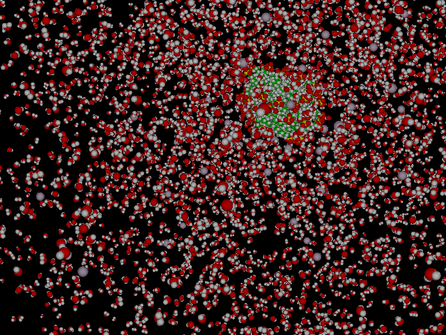

initial snapshot

```python
c = Canvas()
c
```

## MRI

Plot various views of a structural MRI.

```python
import numpy as np
from vispy import io, plot as vp
import vispy
vispy.use("jupyter_rfb")

fig = vp.Fig(bgcolor='k', size=(800, 800), show=False)

vol_data = np.load('./data/mri.npz')['data']
vol_data = np.flipud(np.rollaxis(vol_data, 1))
vol_data = vol_data.astype(np.float32)

clim = [32, 192]
texture_format = "auto"  # None for CPUScaled, "auto" for GPUScaled

vol_pw = fig[0, 0]
v = vol_pw.volume(vol_data, clim=clim, texture_format=texture_format)
vol_pw.view.camera.elevation = 30
vol_pw.view.camera.azimuth = 30
vol_pw.view.camera.scale_factor /= 1.5

shape = vol_data.shape
fig[1, 0].image(vol_data[:, :, shape[2] // 2], cmap='grays', clim=clim,
                fg_color=(0.5, 0.5, 0.5, 1), texture_format=texture_format)
fig[0, 1].image(vol_data[:, shape[1] // 2, :], cmap='grays', clim=clim,
                fg_color=(0.5, 0.5, 0.5, 1), texture_format=texture_format)
fig[1, 1].image(vol_data[shape[0] // 2, :, :].T, cmap='grays', clim=clim,
                fg_color=(0.5, 0.5, 0.5, 1), texture_format=texture_format)

if __name__ == '__main__':
    fig.show(run=True)
```

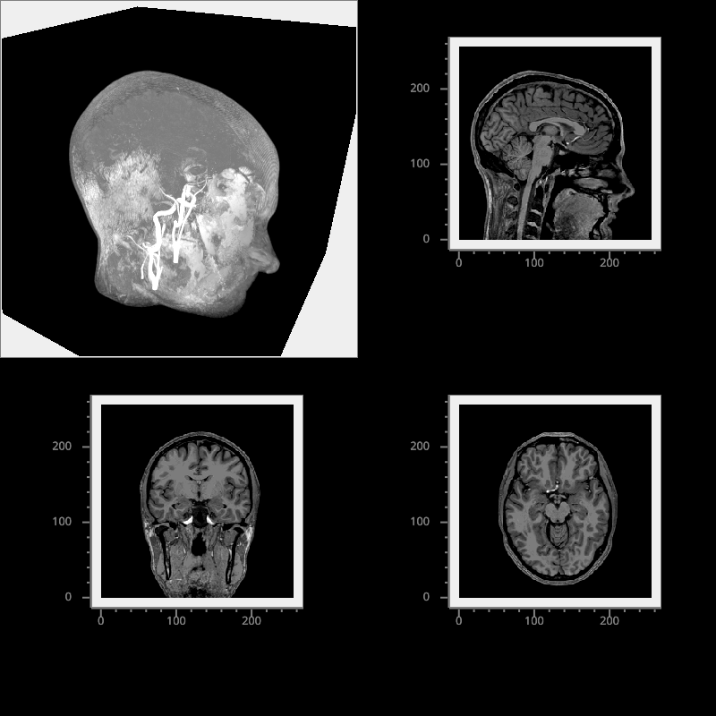

initial snapshot

```python
fig.show()
fig
```

## [Seismic-Canvas](https://github.com/yunzhishi/seismic-canvas)

- **Seismic-Canvas** is an interactive 3D visualization tool mainly designed for seismic data, at the same time also can be useful for any 3D data.
- This tool is based on **VisPy**, a Python library that leverages the computational power of GPUs through the OpenGL library.
- Install: simply run the following command to install from PyPI

  ```
  pip install seismic_canvas
  ```

  (Credit by Yunzhi Shi from UT Austin, 2020)

### Slicing

Add any number of slices to view the slices of your volume using `seismic_canvas.volume_slices` function. For example:

```
visual_nodes = volume_slices(volume, x_pos=[370, 170, 570, 770], y_pos=810, z_pos=120, clim=(-2, 2))
```

[figure not shown]

### Camera

Left click and drag to rotate the camera angle; right click and drag, or scroll mouse wheel, to zoom in and out. Hold **Shift** key, left click and drag to pan move. Press **Space** key to return to the initial view. Press **S** key to save a screenshot PNG file at any time. Press **Esc** key to close the window.

[figure not shown]

### Dragging

Most elements are draggable. Hold **Ctrl** key, the selectable visual nodes will be highlighted when your mouse hovers over them; left click and drag to move the highlighted visual node. The volume slices will update their contents in real-time during dragging. You can also press **D** key to toggle the dragging mode on/off.

[figure not shown]

### MemMap

Compatible to [numpy memory map (https://docs.scipy.org/doc/numpy/reference/generated/numpy.memmap.html). For example, reading in a binary data file contatining a 3D seismic volume with size 210x920x825 (608MB), Seismic-Canvas takes ~700MB RAM (Windows PyQt5 backend).

```
volume = np.fromfile('./CostaRica_seismic.dat', '>f4').reshape(825, 920, 210)
```

Instead, reading in the same file using numpy memory map, Seismic-Canvas takes only ~82MB RAM (Windows PyQt5 backend), and significantly reduces the launch time.

```
volume = np.memmap('./CostaRica_seismic.dat', dtype='>f4', mode='r', shape=(825, 920, 210))
```

### Reproducibility

When you drag and arrange everything on the canvas, press **A** key to print out a collection of useful parameters that can be used to reproduce the current canvas setting.

[figure not shown]

### MRI demo

See [`simple_demo.py`](./examples/simple_demo.py) for a simple demo. [`vispy/util/fetching.py`](https://github.com/vispy/vispy/blob/master/vispy/util/fetching.py) will automatically download this example data.

[figure not shown]

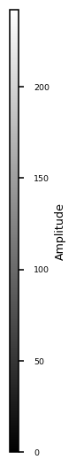

```python
import numpy as np
from seismic_canvas import (SeismicCanvas, volume_slices, XYZAxis, Colorbar)
import vispy
vispy.use("jupyter_rfb")

if __name__ == '__main__':

  from vispy import io
  volume = np.load('./data/mri.npz')['data']
  volume = volume.transpose(2, 0, 1)[:, :, ::-1]
  axis_scales = (1, 1, 1) # isotropoic axes

  visual_nodes = volume_slices(volume,
    x_pos=100, y_pos=128, z_pos=30,
    seismic_coord_system=False)
  xyz_axis = XYZAxis(seismic_coord_system=False)
  colorbar = Colorbar(cmap='grays', clim=(volume.min(), volume.max()),
                      label_str='Amplitude', label_size=8, tick_size=6)


  # Run the canvas.
  canvas = SeismicCanvas(title='Simple Demo',
                         visual_nodes=visual_nodes,
                         xyz_axis=xyz_axis,
                         colorbar=colorbar,
                         # Set the option below=0 will hide the colorbar region
                         # colorbar_region_ratio=0,
                         axis_scales=axis_scales,
                         # Manual camera setting below.
                         # auto_range=False,
                         # scale_factor=972.794,
                         # center=(434.46, 545.63, 10.26),
                         fov=30,
                         elevation=36,
                         azimuth=45,
                         zoom_factor=1.2 # >1: zoom in; <1: zoom out
                         )
  canvas.measure_fps()
  canvas.app.run()
```

### Seismic demo

Also try `osv_F3_demo.py` to check out the results from this research: xinwucwp/osv. You can download all the binary data volumes from this [Google Drive link](https://drive.google.com/drive/folders/1SqEOYIi6MV0PNKazuZ50R_qjLA0VWBM7?usp=sharing).

### Seismic demo

Using 2D markers to visualize a randomly generated well logs.

[figure not shown]

### Seismic demo

Using triangle mesh surfaces to visualize `FaultSkin`s.

[figure not shown]

### Seismic demo

A dark themed example with a z-axis-up axis legend:

[figure not shown]

# 下节课预告

[figure not shown]